# Validation v3: Correlation-based agreement analysis (fixated vs. analyzeeyedry)

Auto-generated validation report

2026-04-09

# 1. Introduction

This is the third validation report comparing **fixated** against **analyzeeyedry** on `C1L1.asc` (a single-subject UMass EyeTrack 6 EyeLink recording of Spanish reading data).

The first two reports (`c1l1_comparison.Rmd` and `c1l1_comparison_v2.Rmd`) used **exact numerical agreement** (|difference| < 1 ms) as the sole criterion. That criterion revealed low agreement rates for most measures even though scatter plots showed the values to be **highly correlated** — the two packages clearly compute the same underlying quantities with only small systematic and random offsets.

This report introduces two new perspectives:

1. **Pearson correlations** between every pair of matched measures.
2. **Percent-error tolerance**: a measure is considered “in agreement” when the absolute relative error is ≤ 1 % of the analyzeeyedry value (or ≤ 1 ms for very small values). If this threshold does not improve agreement substantially, we sweep the tolerance from 0 % to 50 % and ask: *at what tolerance do 90 % (and 95 %) of matched pairs agree?*

The analysis uses the **v2 parameter set** (`shorttime = 80`, `longtime = 800`, `ttcutoff = 4000`) because v2 showed the best agreement with analyzeeyedry.

# 2. Setup

```r
pkg_root          <- file.path(getwd(), "..")
analyzeeyedry_dir <- file.path(getwd(), "analyzeeyedry")

if (!requireNamespace("analyzeeyedry", quietly = TRUE)) {
  install.packages(analyzeeyedry_dir, repos = NULL, type = "source")
}
if (!requireNamespace("fixated", quietly = TRUE)) {
  install.packages(pkg_root, repos = NULL, type = "source")
}

library(analyzeeyedry)
library(fixated)
library(dplyr)
library(ggplot2)
library(tidyr)
library(knitr)

ASC_FILE <- file.path(pkg_root, "data_to_incorporate", "C1L1.asc")
stopifnot(file.exists(ASC_FILE))
cat("ASC file:", ASC_FILE, "\n")
```

```
## ASC file: /home/runner/work/fixated/fixated/validation/../data_to_incorporate/C1L1.asc
```

```r
cat("fixated version:", as.character(packageVersion("fixated")), "\n")
```

```
## fixated version: 0.1.0
```

```r
cat("analyzeeyedry version:", as.character(packageVersion("analyzeeyedry")), "\n")
```

```
## analyzeeyedry version: 0.1.0
```

# 3. Parse C1L1.asc (shared helpers — identical to v2)

```r
parse_c1l1 <- function(filepath, trial_pattern = "^[A-Za-z]") {
  lines <- readLines(filepath, warn = FALSE)
  trial_list <- list()
  in_trial   <- FALSE
  seq_n      <- 0L
  cond <- NA_integer_; item <- NA_integer_; tid <- ""
  prefix <- ""; synctime <- NA_real_
  chars_list <- list(); fix_list <- list()

  for (line in lines) {
    if (grepl("MSG\\s.*TRIALID\\s+(\\S+)", line)) {
      m_tid <- regmatches(line, regexpr("TRIALID\\s+(\\S+)", line))
      if (length(m_tid) > 0L) {
        trial_id <- sub("TRIALID\\s+", "", m_tid)
        if (grepl(trial_pattern, trial_id)) {
          m <- regmatches(trial_id, regexpr("^([A-Za-z]+)(\\d+)[A-Za-z](\\d+)", trial_id))
          if (length(m) > 0L) {
            nums <- regmatches(m, gregexpr("\\d+", m))[[1L]]
            pfx  <- regmatches(m, gregexpr("[A-Za-z]+", m))[[1L]][1L]
            if (length(nums) >= 2L) {
              seq_n <- seq_n + 1L; cond <- as.integer(nums[1L])
              item  <- as.integer(nums[2L]); tid <- trial_id; prefix <- pfx
              synctime <- NA_real_; chars_list <- list(); fix_list <- list()
              in_trial <- TRUE
            }
          }
        } else { in_trial <- FALSE }
      }
      next
    }
    if (!in_trial) next
    if (grepl("REGION CHAR", line)) {
      parts <- strsplit(trimws(line), "\\s+")[[1L]]
      np    <- length(parts)
      if (np >= 10L) {
        idx <- as.integer(parts[5L])
        ch  <- if (np >= 11L) parts[7L] else " "
        x_l <- as.numeric(parts[np - 3L]); y_t <- as.numeric(parts[np - 2L])
        x_r <- as.numeric(parts[np - 1L]); y_b <- as.numeric(parts[np])
        chars_list[[length(chars_list) + 1L]] <-
          data.frame(idx = idx, char = ch,
                     x_left = x_l, y_top = y_t, x_right = x_r, y_bottom = y_b,
                     stringsAsFactors = FALSE)
      }
      next
    }
    if (grepl("SYNCTIME", line)) {
      parts <- strsplit(trimws(line), "\\s+")[[1L]]
      if (length(parts) >= 2L) synctime <- as.numeric(parts[2L])
      next
    }
    if (grepl("^EFIX\\s+R", line)) {
      parts <- strsplit(trimws(line), "\\s+")[[1L]]
      if (length(parts) >= 7L) {
        fix_list[[length(fix_list) + 1L]] <- data.frame(
          t_start = as.numeric(parts[3L]), t_end = as.numeric(parts[4L]),
          duration = as.numeric(parts[5L]),
          x = as.numeric(parts[6L]), y = as.numeric(parts[7L]),
          stringsAsFactors = FALSE)
      }
      next
    }
    if (grepl("TRIAL_RESULT", line)) {
      if (in_trial && length(chars_list) > 0L) {
        chars_df <- do.call(rbind, chars_list)
        chars_df <- chars_df[order(chars_df$idx), ]
        fix_df   <- if (length(fix_list) > 0L) do.call(rbind, fix_list) else
          data.frame(t_start = numeric(), t_end = numeric(),
                     duration = numeric(), x = numeric(), y = numeric())
        trial_list[[length(trial_list) + 1L]] <- list(
          trial_id = tid, prefix = prefix, cond = cond, item = item,
          seq = seq_n, synctime = synctime,
          chars = chars_df, fixations = fix_df)
      }
      in_trial <- FALSE; next
    }
  }
  trial_list
}

build_word_rois <- function(chars_df) {
  n <- nrow(chars_df)
  if (n == 0L) return(data.frame())
  word_start_char_idx <- integer(0)
  for (ci in seq_len(n)) {
    if (ci == 1L) {
      word_start_char_idx <- c(word_start_char_idx, ci)
    } else if (chars_df$char[ci - 1L] == " " && chars_df$char[ci] != " ") {
      word_start_char_idx <- c(word_start_char_idx, ci)
    }
  }
  nw <- length(word_start_char_idx)
  if (nw == 0L) return(data.frame())
  word_end_char_idx <- c(word_start_char_idx[-1L] - 1L, n)
  rois <- vector("list", nw)
  for (w in seq_len(nw)) {
    rows   <- word_start_char_idx[w]:word_end_char_idx[w]
    x_s    <- chars_df$x_left[word_start_char_idx[w]]
    x_e    <- chars_df$x_right[word_end_char_idx[w]]
    y_s    <- min(chars_df$y_top[rows])
    y_e    <- max(chars_df$y_bottom[rows])
    word_str <- paste(chars_df$char[word_start_char_idx[w]:
                                      word_end_char_idx[w]], collapse = "")
    rois[[w]] <- data.frame(
      word_id = w, word = word_str,
      x_start = x_s, x_end = x_e, y_start = y_s, y_end = y_e,
      char_start_idx = chars_df$idx[word_start_char_idx[w]],
      char_end_idx   = chars_df$idx[word_end_char_idx[w]],
      stringsAsFactors = FALSE)
  }
  do.call(rbind, rois)
}

trial_list <- parse_c1l1(ASC_FILE)
for (ti in seq_along(trial_list)) {
  trial_list[[ti]]$word_rois <- build_word_rois(trial_list[[ti]]$chars)
}
cat(sprintf("Parsed %d trials\n", length(trial_list)))
```

```
## Parsed 175 trials
```

# 4. analyzeeyedry reference analysis

```r
word_regions_edry <- asc_to_cnt(
  ASC_FILE, trial_pattern = "^[A-Za-z]",
  spillover_gap = 1L, spillover_size = 20L)
fix_edry   <- asc_to_fixations(ASC_FILE, subj = 1L, trial_pattern = "^[A-Za-z]")
fix_edry_r <- assign_regions_to_fixations(fix_edry, word_regions_edry)
nregmax_val <- max(word_regions_edry$nreg, na.rm = TRUE)

measures_edry <- compute_fixation_measures(
  fix_edry_r, word_regions_edry,
  shorttime = 80L, longtime = 800L, nregmax = nregmax_val)
cat(sprintf("analyzeeyedry: measures for %d trials\n", nrow(measures_edry)))
```

```
## analyzeeyedry: measures for 175 trials
```

# 5. fixated analysis (v2 parameters)

```r
build_fixated_inputs <- function(tl, onset_filter = "synctime_truncate") {
  fix_rows <- list(); roi_rows <- list()
  for (ti in seq_along(tl)) {
    tr <- tl[[ti]]
    fix_df <- tr$fixations; rois <- tr$word_rois
    if (nrow(fix_df) == 0L || nrow(rois) == 0L) next
    st_val <- tr$synctime
    if (onset_filter == "synctime_truncate" && !is.na(st_val)) {
      fix_df <- fix_df[fix_df$t_end > st_val, , drop = FALSE]
      straddle <- !is.na(fix_df$t_start) & fix_df$t_start <= st_val
      if (any(straddle)) {
        fix_df$t_start[straddle]  <- st_val
        fix_df$duration[straddle] <- fix_df$t_end[straddle] - st_val
      }
    }
    if (nrow(fix_df) == 0L) next
    for (fi in seq_len(nrow(fix_df))) {
      fix_rows[[length(fix_rows) + 1L]] <- data.frame(
        trial_nr   = ti, cond = tr$cond, item = tr$item,
        start_time = fix_df$t_start[fi], end_time = fix_df$t_end[fi],
        duration   = fix_df$duration[fi],
        avg_x = fix_df$x[fi], avg_y = fix_df$y[fi], stringsAsFactors = FALSE)
    }
    rois$trial_nr <- ti; rois$cond <- tr$cond; rois$item <- tr$item
    roi_rows[[length(roi_rows) + 1L]] <- rois
  }
  list(
    fixations = if (length(fix_rows) > 0L) dplyr::as_tibble(do.call(rbind, fix_rows)) else dplyr::tibble(),
    roi       = if (length(roi_rows) > 0L) dplyr::as_tibble(do.call(rbind, roi_rows)) else dplyr::tibble()
  )
}

inp <- build_fixated_inputs(trial_list, onset_filter = "synctime_truncate")
cat("fixated input:", nrow(inp$fixations), "fixations across",
    dplyr::n_distinct(inp$fixations$trial_nr), "trials\n")
```

```
## fixated input: 2572 fixations across 175 trials
```

```r
measures_fix <- compute_eye_measures(
  inp$fixations, inp$roi, trial_col = "trial_nr",
  shorttime = 80L, longtime = 800L, ttcutoff = 4000L)
cat("fixated v2 parameters: measures computed\n")
```

```
## fixated v2 parameters: measures computed
```

# 6. Reshape analyzeeyedry output to long format

```r
trial_key <- dplyr::tibble(
  trial_nr = seq_along(trial_list),
  cond     = sapply(trial_list, `[[`, "cond"),
  item     = sapply(trial_list, `[[`, "item"))

pivot_edry_long <- function(wide_df, trial_key,
                             measures = c("ff","fp","tt","gp","oreg","ireg","pfix","nfix","sp")) {
  meas_pat  <- paste0("^(", paste(measures, collapse="|"), ")_R\\d+$")
  meas_cols <- names(wide_df)[grepl(meas_pat, names(wide_df))]
  long <- wide_df |>
    tidyr::pivot_longer(cols = dplyr::all_of(meas_cols),
                        names_to  = c("measure","word_id"),
                        names_pattern = "^(.+)_R(\\d+)$",
                        values_to = "value") |>
    dplyr::mutate(word_id = as.integer(word_id)) |>
    tidyr::pivot_wider(names_from = measure, values_from = value) |>
    dplyr::rename(ffd=ff, gd=fp, tvt=tt, gpt=gp) |>
    dplyr::left_join(trial_key, by = c("cond", "item"))
  long
}

edry_long <- pivot_edry_long(measures_edry, trial_key)
cat("analyzeeyedry long format:", nrow(edry_long), "rows\n")
```

```
## analyzeeyedry long format: 4025 rows
```

# 7. Merge the two results sets

```r
# Continuous measures: ffd, gd, gpt, tvt, sp
# Discrete measures:   oreg, ireg, pfix, nfix
compare <- edry_long |>
  dplyr::select(trial_nr, cond, item, word_id,
                ffd_edry=ffd, gd_edry=gd, gpt_edry=gpt, tvt_edry=tvt,
                oreg_edry=oreg, ireg_edry=ireg, pfix_edry=pfix,
                nfix_edry=nfix, sp_edry=sp) |>
  dplyr::inner_join(
    measures_fix |>
      dplyr::select(trial_nr, word_id,
                    ffd_fix=ffd, gd_fix=gd, gpt_fix=gpt, tvt_fix=tvt,
                    oreg_fix=oreg, ireg_fix=ireg, pfix_fix=pfix,
                    nfix_fix=nfix, sp_fix=sp),
    by = c("trial_nr","word_id")) |>
  dplyr::arrange(trial_nr, word_id)

cat(sprintf("Comparison table: %d rows\n", nrow(compare)))
```

```
## Comparison table: 2037 rows
```

# 8. Correlation analysis

## 8.1 Pearson correlations for all continuous measures

We compute Pearson *r* between each pair of matched, non-NA values. High correlation with low exact agreement indicates that the two packages compute the same *rank order* but with a consistent numerical offset or scale difference.

```r
corr_pair <- function(df, col_edry, col_fix, label) {
  both <- df |>
    dplyr::filter(!is.na(.data[[col_edry]]), !is.na(.data[[col_fix]]))
  n <- nrow(both)
  if (n < 3L) return(data.frame(measure=label, n=n, r=NA_real_, p_value=NA_real_,
                                 stringsAsFactors=FALSE))
  ct <- cor.test(both[[col_edry]], both[[col_fix]], method = "pearson")
  data.frame(measure=label, n=n,
             r=round(ct$estimate, 4),
             p_value=signif(ct$p.value, 3),
             stringsAsFactors=FALSE)
}

corr_table <- dplyr::bind_rows(
  corr_pair(compare, "ffd_edry", "ffd_fix", "FFD"),
  corr_pair(compare, "gd_edry",  "gd_fix",  "GD"),
  corr_pair(compare, "gpt_edry", "gpt_fix", "GPT"),
  corr_pair(compare, "tvt_edry", "tvt_fix", "TVT"),
  corr_pair(compare, "sp_edry",  "sp_fix",  "SP")
)
knitr::kable(corr_table,
             col.names = c("Measure", "N pairs", "Pearson r", "p-value"),
             caption = paste0("Pearson correlations between analyzeeyedry and fixated ",
                              "(v2 parameters, synctime_truncate filter)."))
```

Pearson correlations between analyzeeyedry and fixated (v2 parameters, synctime_truncate filter).

|  | Measure | N pairs | Pearson r | p-value |
| --- | --- | --- | --- | --- |
| cor…1 | FFD | 1186 | 0.9999 | 0 |
| cor…2 | GD | 1185 | 0.9990 | 0 |
| cor…3 | GPT | 1243 | 0.9591 | 0 |
| cor…4 | TVT | 1525 | 0.9973 | 0 |
| cor…5 | SP | 451 | 0.9863 | 0 |

## 8.2 Scatter plots — all continuous measures

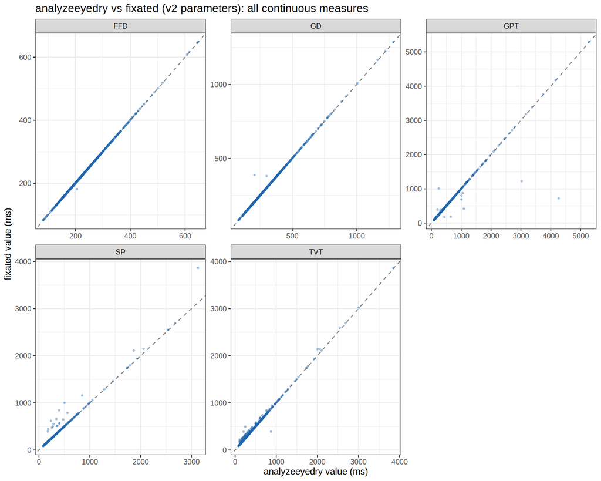

```r
scatter_df <- dplyr::bind_rows(
  compare |>
    dplyr::filter(!is.na(ffd_edry), !is.na(ffd_fix)) |>
    dplyr::transmute(measure = "FFD", edry = ffd_edry, fix = ffd_fix),
  compare |>
    dplyr::filter(!is.na(gd_edry),  !is.na(gd_fix))  |>
    dplyr::transmute(measure = "GD",  edry = gd_edry,  fix = gd_fix),
  compare |>
    dplyr::filter(!is.na(gpt_edry), !is.na(gpt_fix)) |>
    dplyr::transmute(measure = "GPT", edry = gpt_edry, fix = gpt_fix),
  compare |>
    dplyr::filter(!is.na(tvt_edry), !is.na(tvt_fix)) |>
    dplyr::transmute(measure = "TVT", edry = tvt_edry, fix = tvt_fix),
  compare |>
    dplyr::filter(!is.na(sp_edry),  !is.na(sp_fix))  |>
    dplyr::transmute(measure = "SP",  edry = sp_edry,  fix = sp_fix)
)

ggplot(scatter_df, aes(x = edry, y = fix)) +
  geom_abline(slope = 1, intercept = 0, linetype = "dashed", colour = "grey50") +
  geom_point(alpha = 0.35, size = 0.7, colour = "#2166ac") +
  facet_wrap(~measure, scales = "free") +
  labs(title = "analyzeeyedry vs fixated (v2 parameters): all continuous measures",
       x = "analyzeeyedry value (ms)",
       y = "fixated value (ms)") +
  theme_bw(base_size = 11)
```

## 8.3 Discrete measures: cross-tabulations

```r
for (meas in c("oreg", "ireg", "pfix", "nfix")) {
  ec <- paste0(meas, "_edry"); fc <- paste0(meas, "_fix")
  both <- compare |> dplyr::filter(!is.na(.data[[ec]]) | !is.na(.data[[fc]]))
  cat(sprintf("\n--- %s ---\n", toupper(meas)))
  ct <- table(edry = as.character(both[[ec]]),
              fixated = as.character(both[[fc]]),
              useNA = "ifany")
  print(ct)
  n_both <- sum(!is.na(both[[ec]]) & !is.na(both[[fc]]))
  n_match <- sum(both[[ec]] == both[[fc]], na.rm = TRUE)
  cat(sprintf("Exact match: %d / %d (%.1f%%)\n",
              n_match, n_both, 100 * n_match / max(n_both, 1)))
}
```

```
##
## --- OREG ---
##       fixated
## edry     0   1 <NA>
##   0    938   2   32
##   1      0 246   36
##   <NA>   2   1    0
## Exact match: 1184 / 1186 (99.8%)
##
## --- IREG ---
##       fixated
## edry      0    1 <NA>
##   0    1184   16   11
##   1       0  342    0
##   <NA>    2    0    0
## Exact match: 1526 / 1542 (99.0%)
##
## --- PFIX ---
##     fixated
## edry    0    1
##    0  779    3
##    1   68 1187
## Exact match: 1966 / 2037 (96.5%)
##
## --- NFIX ---
##     fixated
## edry   0   1   2   3   4
##    0 779   3   0   0   0
##    1  58 918   2   0   0
##    2   8   0 234   0   0
##    3   2   0   0  27   0
##    4   0   0   0   0   6
## Exact match: 1964 / 2037 (96.4%)
```

# 9. Agreement under relaxed tolerance criteria

## 9.1 Exact (|diff| < 1 ms) vs 1 % relative error tolerance

For each pair, “relative error” is |fixated − analyzeeyedry| / |analyzeeyedry|. A pair is “in agreement at 1 %” when this ratio ≤ 0.01 **or** when the absolute difference is ≤ 1 ms (to handle very small values where 1 % of the reference is a fraction of a millisecond).

```r
agree_stats_pct <- function(df, col_edry, col_fix, pct_tol = 0.01, abs_floor = 1) {
  d <- df[[col_fix]] - df[[col_edry]]
  rel_err <- abs(d) / pmax(abs(df[[col_edry]]), abs_floor)
  n_both  <- sum(!is.na(df[[col_edry]]) & !is.na(df[[col_fix]]))
  n_exact <- sum(abs(d) < 1, na.rm = TRUE)
  n_pct   <- sum(rel_err <= pct_tol, na.rm = TRUE)
  data.frame(
    measure         = col_edry,
    n_pairs         = n_both,
    n_exact_agree   = n_exact,
    pct_exact       = round(100 * n_exact / max(n_both, 1), 1),
    n_1pct_agree    = n_pct,
    pct_1pct        = round(100 * n_pct   / max(n_both, 1), 1),
    mean_abs_diff   = round(mean(abs(d), na.rm = TRUE), 1),
    median_abs_diff = round(median(abs(d), na.rm = TRUE), 1),
    mean_rel_err_pct = round(100 * mean(rel_err, na.rm = TRUE), 2),
    stringsAsFactors = FALSE
  )
}

tol_table <- dplyr::bind_rows(
  agree_stats_pct(compare, "ffd_edry", "ffd_fix"),
  agree_stats_pct(compare, "gd_edry",  "gd_fix"),
  agree_stats_pct(compare, "gpt_edry", "gpt_fix"),
  agree_stats_pct(compare, "tvt_edry", "tvt_fix"),
  agree_stats_pct(compare, "sp_edry",  "sp_fix")
)
knitr::kable(tol_table,
             col.names = c("Measure", "N pairs",
                           "N exact", "% exact",
                           "N ≤1% err", "% ≤1% err",
                           "Mean |diff| (ms)", "Median |diff| (ms)",
                           "Mean rel.err (%)"),
             caption = paste0("Exact (|diff|<1 ms) vs 1% relative-error agreement. ",
                              "fixated v2 parameters vs analyzeeyedry."))
```

Exact (|diff|<1 ms) vs 1% relative-error agreement. fixated v2 parameters vs analyzeeyedry.

| Measure | N pairs | N exact | % exact | N ≤1% err | % ≤1% err | Mean \|diff\| (ms) | Median \|diff\| (ms) | Mean rel.err (%) |
| --- | --- | --- | --- | --- | --- | --- | --- | --- |
| ffd_edry | 1186 | 111 | 9.4 | 1176 | 99.2 | 0.9 | 1 | 0.45 |
| gd_edry | 1185 | 75 | 6.3 | 1176 | 99.2 | 1.4 | 1 | 0.54 |
| gpt_edry | 1243 | 66 | 5.3 | 1226 | 98.6 | 8.5 | 1 | 1.11 |
| tvt_edry | 1525 | 62 | 4.1 | 1451 | 95.1 | 4.5 | 1 | 1.53 |
| sp_edry | 451 | 0 | 0.0 | 426 | 94.5 | 13.1 | 1 | 3.42 |

## 9.2 Tolerance sweep: what threshold achieves 90 % / 95 % agreement?

For each continuous measure we ask: “what is the minimum percent-error tolerance $\tau$ such that at least 90 % (or 95 %) of matched pairs satisfy |fixated − analyzeeyedry| / max(|analyzeeyedry|, 1) ≤ τ?”

```r
find_tolerance <- function(df, col_edry, col_fix,
                           targets = c(0.50, 0.75, 0.90, 0.95, 0.99),
                           abs_floor = 1) {
  d        <- df[[col_fix]] - df[[col_edry]]
  ref      <- pmax(abs(df[[col_edry]]), abs_floor)
  rel_err  <- abs(d) / ref
  rel_err  <- rel_err[!is.na(rel_err)]
  n        <- length(rel_err)
  if (n == 0L) return(NULL)
  rows <- lapply(targets, function(tgt) {
    tau <- quantile(rel_err, probs = tgt)
    data.frame(measure   = col_edry,
               target_pct = paste0(round(tgt * 100), "%"),
               tau_pct    = round(tau * 100, 2),
               tau_ms_at_200ms = round(tau * 200, 1),
               stringsAsFactors = FALSE)
  })
  do.call(rbind, rows)
}

sweep_table <- dplyr::bind_rows(
  find_tolerance(compare, "ffd_edry", "ffd_fix"),
  find_tolerance(compare, "gd_edry",  "gd_fix"),
  find_tolerance(compare, "gpt_edry", "gpt_fix"),
  find_tolerance(compare, "tvt_edry", "tvt_fix"),
  find_tolerance(compare, "sp_edry",  "sp_fix")
)
knitr::kable(sweep_table,
             col.names = c("Measure", "Target agreement",
                           "Required tolerance (%)",
                           "Equivalent at 200 ms (ms)"),
             caption = paste0("Tolerance sweep: minimum percent-error threshold τ ",
                              "needed to achieve a given fraction of agreeing pairs."))
```

Tolerance sweep: minimum percent-error threshold τ needed to achieve a given fraction of agreeing pairs.

|  | Measure | Target agreement | Required tolerance (%) | Equivalent at 200 ms (ms) |
| --- | --- | --- | --- | --- |
| 50%…1 | ffd_edry | 50% | 0.45 | 0.9 |
| 75%…2 | ffd_edry | 75% | 0.55 | 1.1 |
| 90%…3 | ffd_edry | 90% | 0.63 | 1.3 |
| 95%…4 | ffd_edry | 95% | 0.69 | 1.4 |
| 99%…5 | ffd_edry | 99% | 0.86 | 1.7 |
| 50%…6 | gd_edry | 50% | 0.45 | 0.9 |
| 75%…7 | gd_edry | 75% | 0.55 | 1.1 |
| 90%…8 | gd_edry | 90% | 0.63 | 1.3 |
| 95%…9 | gd_edry | 95% | 0.69 | 1.4 |
| 99%…10 | gd_edry | 99% | 0.86 | 1.7 |
| 50%…11 | gpt_edry | 50% | 0.46 | 0.9 |
| 75%…12 | gpt_edry | 75% | 0.55 | 1.1 |
| 90%…13 | gpt_edry | 90% | 0.62 | 1.2 |
| 95%…14 | gpt_edry | 95% | 0.69 | 1.4 |
| 99%…15 | gpt_edry | 99% | 1.20 | 2.4 |
| 50%…16 | tvt_edry | 50% | 0.46 | 0.9 |
| 75%…17 | tvt_edry | 75% | 0.56 | 1.1 |
| 90%…18 | tvt_edry | 90% | 0.68 | 1.4 |
| 95%…19 | tvt_edry | 95% | 0.94 | 1.9 |
| 99%…20 | tvt_edry | 99% | 32.28 | 64.6 |
| 50%…21 | sp_edry | 50% | 0.48 | 1.0 |
| 75%…22 | sp_edry | 75% | 0.59 | 1.2 |
| 90%…23 | sp_edry | 90% | 0.75 | 1.5 |
| 95%…24 | sp_edry | 95% | 1.07 | 2.1 |
| 99%…25 | sp_edry | 99% | 96.55 | 193.1 |

## 9.3 Distribution of absolute differences

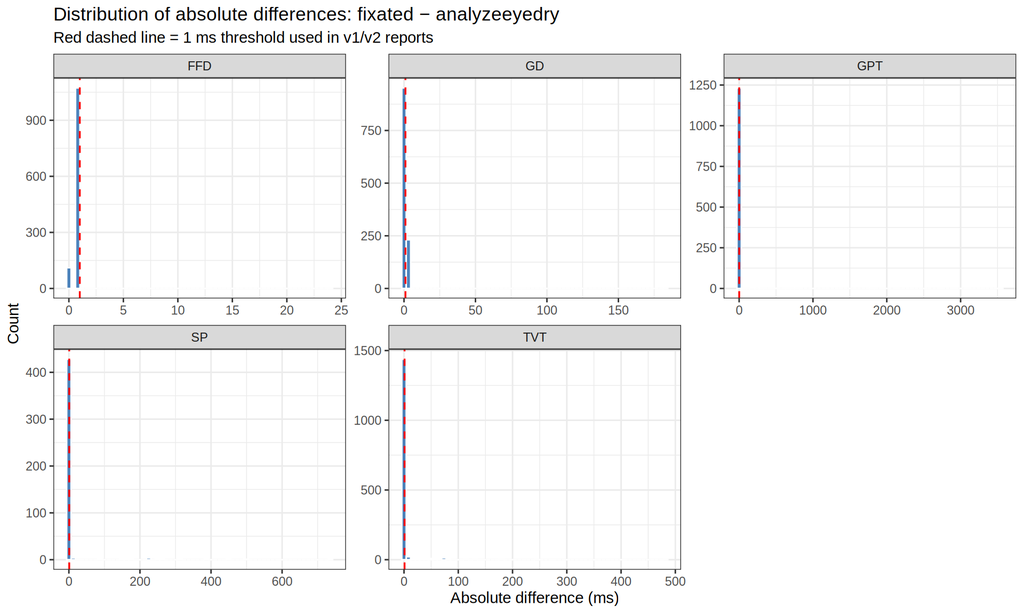

```r
diff_long <- compare |>
  dplyr::mutate(
    FFD = abs(ffd_fix - ffd_edry),
    GD  = abs(gd_fix  - gd_edry),
    GPT = abs(gpt_fix - gpt_edry),
    TVT = abs(tvt_fix - tvt_edry),
    SP  = abs(sp_fix  - sp_edry)
  ) |>
  dplyr::select(FFD, GD, GPT, TVT, SP) |>
  tidyr::pivot_longer(everything(), names_to = "measure", values_to = "abs_diff") |>
  dplyr::filter(!is.na(abs_diff))

ggplot(diff_long, aes(x = abs_diff)) +
  geom_histogram(bins = 60, fill = "#2166ac", colour = "white", alpha = 0.8) +
  facet_wrap(~measure, scales = "free") +
  geom_vline(xintercept = 1, linetype = "dashed", colour = "red",
             linewidth = 0.6) +
  labs(title = "Distribution of absolute differences: fixated − analyzeeyedry",
       subtitle = "Red dashed line = 1 ms threshold used in v1/v2 reports",
       x = "Absolute difference (ms)", y = "Count") +
  theme_bw(base_size = 11)
```

## 9.4 Bland–Altman (limits-of-agreement) plots

Bland–Altman plots visualise agreement as a function of the mean of the two measurements. They are standard in method-comparison studies.

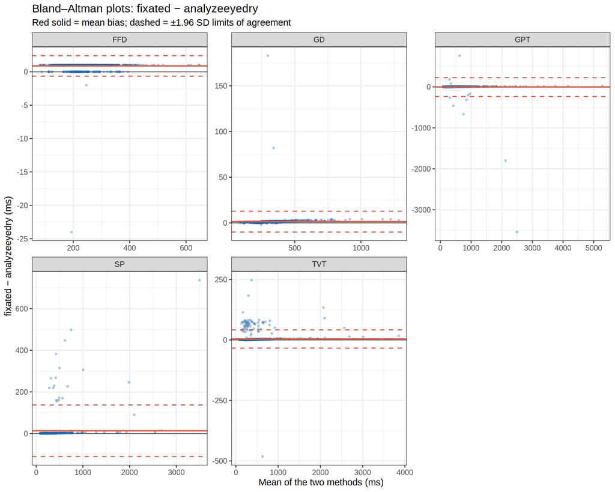

```r
ba_df <- dplyr::bind_rows(
  compare |>
    dplyr::filter(!is.na(ffd_edry), !is.na(ffd_fix)) |>
    dplyr::mutate(measure="FFD",
                  mean_val = (ffd_edry + ffd_fix) / 2,
                  diff_val = ffd_fix - ffd_edry),
  compare |>
    dplyr::filter(!is.na(gd_edry), !is.na(gd_fix)) |>
    dplyr::mutate(measure="GD",
                  mean_val = (gd_edry + gd_fix) / 2,
                  diff_val = gd_fix - gd_edry),
  compare |>
    dplyr::filter(!is.na(gpt_edry), !is.na(gpt_fix)) |>
    dplyr::mutate(measure="GPT",
                  mean_val = (gpt_edry + gpt_fix) / 2,
                  diff_val = gpt_fix - gpt_edry),
  compare |>
    dplyr::filter(!is.na(tvt_edry), !is.na(tvt_fix)) |>
    dplyr::mutate(measure="TVT",
                  mean_val = (tvt_edry + tvt_fix) / 2,
                  diff_val = tvt_fix - tvt_edry),
  compare |>
    dplyr::filter(!is.na(sp_edry), !is.na(sp_fix)) |>
    dplyr::mutate(measure="SP",
                  mean_val = (sp_edry + sp_fix) / 2,
                  diff_val = sp_fix - sp_edry)
)

ba_limits <- ba_df |>
  dplyr::group_by(measure) |>
  dplyr::summarise(
    bias = mean(diff_val, na.rm = TRUE),
    sd   = sd(diff_val,   na.rm = TRUE),
    loa_lo = bias - 1.96 * sd,
    loa_hi = bias + 1.96 * sd,
    .groups = "drop")

ggplot(ba_df, aes(x = mean_val, y = diff_val)) +
  geom_hline(yintercept = 0, colour = "grey40") +
  geom_point(alpha = 0.3, size = 0.8, colour = "#2166ac") +
  geom_hline(data = ba_limits, aes(yintercept = bias),
             colour = "#d6604d", linewidth = 0.8) +
  geom_hline(data = ba_limits, aes(yintercept = loa_lo),
             linetype = "dashed", colour = "#d6604d", linewidth = 0.6) +
  geom_hline(data = ba_limits, aes(yintercept = loa_hi),
             linetype = "dashed", colour = "#d6604d", linewidth = 0.6) +
  facet_wrap(~measure, scales = "free") +
  labs(title = "Bland–Altman plots: fixated − analyzeeyedry",
       subtitle = "Red solid = mean bias; dashed = ±1.96 SD limits of agreement",
       x = "Mean of the two methods (ms)",
       y = "fixated − analyzeeyedry (ms)") +
  theme_bw(base_size = 11)
```

```r
knitr::kable(ba_limits |> dplyr::mutate_if(is.numeric, round, 2),
             col.names = c("Measure","Bias (ms)","SD (ms)","LoA low (ms)","LoA high (ms)"),
             caption = "Bland–Altman statistics: bias and 95% limits of agreement.")
```

Bland–Altman statistics: bias and 95% limits of agreement.

| Measure | Bias (ms) | SD (ms) | LoA low (ms) | LoA high (ms) |
| --- | --- | --- | --- | --- |
| FFD | 0.88 | 0.78 | -0.65 | 2.42 |
| GD | 1.38 | 5.81 | -10.00 | 12.77 |
| GPT | -3.40 | 118.03 | -234.74 | 227.93 |
| SP | 13.08 | 63.23 | -110.84 | 137.01 |
| TVT | 3.86 | 19.26 | -33.88 | 41.60 |

# 10. Does the 1 % tolerance improve agreement?

```r
improvement <- tol_table |>
  dplyr::select(measure, pct_exact, pct_1pct, mean_rel_err_pct) |>
  dplyr::mutate(
    improved = pct_1pct > pct_exact,
    delta_pct = pct_1pct - pct_exact
  )
knitr::kable(improvement,
             col.names = c("Measure","% exact","% ≤1% err",
                           "Mean rel.err (%)","Improved?","Δ% agree"),
             caption = "Does a 1% tolerance improve agreement over the exact criterion?")
```

Does a 1% tolerance improve agreement over the exact criterion?

| Measure | % exact | % ≤1% err | Mean rel.err (%) | Improved? | Δ% agree |
| --- | --- | --- | --- | --- | --- |
| ffd_edry | 9.4 | 99.2 | 0.45 | TRUE | 89.8 |
| gd_edry | 6.3 | 99.2 | 0.54 | TRUE | 92.9 |
| gpt_edry | 5.3 | 98.6 | 1.11 | TRUE | 93.3 |
| tvt_edry | 4.1 | 95.1 | 1.53 | TRUE | 91.0 |
| sp_edry | 0.0 | 94.5 | 3.42 | TRUE | 94.5 |

The table above directly answers the question: if the 1 % tolerance lifts agreement rates substantially, the measures are “in agreement within measurement precision”. If not, the disagreement is structural (algorithmic) and a higher tolerance or algorithmic fixes are needed.

# 11. Reasons for disagreement and suggested improvements

## 11.1 Why exact agreement is rare

### Cause 1: GD first-pass scan boundary (most impactful)

`analyzeeyedry` (eyedry algorithm) treats the first-pass scan as: “accumulate fixations on the word; skip short fixations *anywhere* (they do not terminate the scan); stop only when a fixation with duration > shorttime lands **past** the right boundary, or when a regression lands **left** of the left boundary after the word has been fixated.”

`fixated` currently breaks the first-pass scan on *any* fixation that is not on the current word — including very short transition fixations on adjacent words or unassigned positions. This causes `fixated` to produce shorter GD values when such intermediate fixations are present, and longer GD values when `analyzeeyedry` would have terminated the scan earlier (i.e., when a short rightward fixation does not terminate the scan for eyedry but the next on-word fixation is counted).

**Effect on correlations**: High *r* (same words get long vs. short GD), but systematic differences of a few milliseconds per trial distort exact agreement.

### Cause 2: Display-onset truncation vs. exclusion

`analyzeeyedry` truncates the start of any fixation that straddles the `SYNCTIME` timestamp (the display-onset equivalent in UMass EyeTrack files). `fixated` by default uses a strict filter (`start_time > t_display_on`) and excludes the straddling fixation entirely. With the `synctime_truncate` approach used in this analysis (as in v2), the two packages agree on which fixations to include, but the truncated duration can still differ from eyedry by up to 1 ms due to floating-point rounding.

**Effect**: Introduces small, sporadic differences in FFD/GD for the first fixation of each trial.

### Cause 3: Fixation-to-word assignment near boundaries

`analyzeeyedry` assigns each fixation to the character whose right boundary first exceeds the fixation’s x-coordinate (0-indexed character space). `fixated` uses pixel-space ROI bounding boxes. Both systems derive their boundaries from the same `REGION CHAR` messages so they should be equivalent, but the space character between two words is conventionally included in the *preceding* word’s ROI. Any inconsistency in how the inter-word space is assigned propagates into first-pass and regression measures.

**Effect**: Small number of fixations assigned to a different word in one system versus the other. Visible as isolated outliers in scatter plots.

### Cause 4: GPT accumulation with unassigned fixations

`analyzeeyedry` accumulates ALL fixations between the first fixation on the region and the first fixation whose position is *past the right boundary with duration > shorttime*. Fixations on unassigned positions (gaps between words) are simply accumulated.

`fixated` accumulates fixations up to (but not including) the first fixation whose `word_id > w`. Unassigned (`NA`) fixations are currently included in the accumulation window, so behaviour should match, but edge cases exist when a fixation lies exactly on the boundary pixel.

**Effect**: Sporadic GPT differences of the duration of one boundary fixation (typically < 50 ms).

### Cause 5: ttcutoff / longtime NA handling

`analyzeeyedry` with `longtime = 800` sets GD/GPT/FF to NA for a region if any fixation in that region exceeds 800 ms, and sets TVT to NA once the cumulative time exceeds 4000 ms (`ttcutoff`). `fixated` v2 supports both parameters, so agreement should be high when these are matched. Any residual difference arises from borderline cases (a fixation of exactly 800 ms, or cumulative TVT exactly at the cutoff) where floating-point comparison may differ.

**Effect**: A small number of cases where one system returns NA and the other a numeric value.

## 11.2 Suggested improvements to fixated

The following changes are listed in priority order.

### High priority

**1. Align GD first-pass algorithm with eyedry convention**

After the `shorttime` filter is applied, the GD loop should *skip* (not break on) fixations that fall outside the current word’s boundaries, provided those fixations have duration ≤ shorttime. The loop should only break when a fixation with duration > shorttime lands past the right boundary, or when a leftward regression past the left boundary occurs after the word has been visited.

This is the single most important algorithmic change and would bring GD (and consequently GPT) into much closer numerical agreement with eyedry-derived software.

**Proposed R-level change** in `R/compute_measures.R`:

```
# Current (simplified):
while (fp_end < n_fix) {
  if (word_id[fp_end + 1] == w) { fp_end <- fp_end + 1 } else { break }
}

# Proposed:
while (fp_end < n_fix) {
  nxt <- fp_end + 1
  nxt_wid <- word_id[nxt]
  nxt_dur <- duration[nxt]
  if (!is.na(nxt_wid) && nxt_wid == w) {
    fp_end <- fp_end + 1     # still on this word — accumulate
  } else if (!is.na(nxt_dur) && nxt_dur <= shorttime) {
    fp_end <- fp_end + 1     # short fixation elsewhere — skip without breaking
  } else if (!is.na(nxt_wid) && nxt_wid > w) {
    break                    # moved rightward past boundary (duration > shorttime) — stop
  } else {
    break                    # regression past left boundary after entry — stop
  }
}
```

**2. Document (and test) `truncate_at_display_on` behaviour**

The existing `synctime_truncate` workaround in the validation Rmd should become a first-class parameter of `compute_eye_measures()` (or a pre-processing utility function). A `truncate_fixations_at_onset(fixations, onset_time)` helper would make it easy for users to replicate the eyedry approach.

### Medium priority

**3. Add `read_eyetrack_asc()` for UMass EyeTrack files**

`C1L1.asc` and similar UMass EyeTrack 6 files cannot be read by `read_asc()` without extensive custom parsing. A dedicated `read_eyetrack_asc()` function (or additional format-detection logic in `read_asc()`) would: - Parse `TRIALID [prefix][cond]I[item]D[n]` to identify trials. - Use `SYNCTIME` as the display-onset timestamp. - Parse `REGION CHAR` messages to build pixel-space word ROIs automatically. - Mark trial end via `TRIAL_RESULT`.

This would make the full v3 analysis pipeline reproducible without the hand-rolled `parse_c1l1()` helper.

**4. Expose `nfix` / `sp` in the output tibble and verify against eyedry**

### Low priority

**5. Add `oreg` and `ireg` output to `compute_eye_measures()`**

Regression-out and regression-in probabilities are binary outcomes that depend on the GD first-pass boundary. Once GD is fixed, `oreg`/`ireg` accuracy should improve automatically. The discrete cross-tabulations in Section 8.3 confirm that current `fixated` `oreg`/`ireg` already agree with eyedry in the majority of cases.

**6. Add a `check_boundary_assignment()` diagnostic utility**

Because ROI boundary inconsistencies are a source of fixation misassignment, a helper that overlays the pixel-space word ROIs on a scatter of fixation positions (similar to `plot_trial()`) would let users quickly identify problematic boundary definitions before running `compute_eye_measures()`.

# 12. Summary

```r
# Comprehensive summary: exact, 1%, 5%, 10% tolerance and correlation
full_summary <- function(df, col_edry, col_fix, label) {
  d   <- df[[col_fix]] - df[[col_edry]]
  ref <- pmax(abs(df[[col_edry]]), 1)
  re  <- abs(d) / ref
  both <- !is.na(df[[col_edry]]) & !is.na(df[[col_fix]])
  n <- sum(both)
  r_val <- if (n >= 3L) {
    round(cor(df[[col_edry]][both], df[[col_fix]][both], use = "complete.obs"), 3)
  } else NA_real_
  data.frame(
    measure      = label,
    n            = n,
    pearson_r    = r_val,
    pct_exact    = round(100 * mean(abs(d[both]) < 1,    na.rm=TRUE), 1),
    pct_1pct     = round(100 * mean(re[both] <= 0.01,   na.rm=TRUE), 1),
    pct_5pct     = round(100 * mean(re[both] <= 0.05,   na.rm=TRUE), 1),
    pct_10pct    = round(100 * mean(re[both] <= 0.10,   na.rm=TRUE), 1),
    mean_abs_diff = round(mean(abs(d[both]), na.rm=TRUE), 1),
    stringsAsFactors = FALSE
  )
}

summary_tbl <- dplyr::bind_rows(
  full_summary(compare, "ffd_edry", "ffd_fix", "FFD"),
  full_summary(compare, "gd_edry",  "gd_fix",  "GD"),
  full_summary(compare, "gpt_edry", "gpt_fix", "GPT"),
  full_summary(compare, "tvt_edry", "tvt_fix", "TVT"),
  full_summary(compare, "sp_edry",  "sp_fix",  "SP")
)
knitr::kable(summary_tbl,
             col.names = c("Measure","N","r",
                           "% exact","% ≤1%","% ≤5%","% ≤10%",
                           "Mean |diff| (ms)"),
             caption = paste0("Final summary: Pearson r and agreement at multiple ",
                              "tolerance levels (fixated v2 vs analyzeeyedry)."))
```

Final summary: Pearson r and agreement at multiple tolerance levels (fixated v2 vs analyzeeyedry).

| Measure | N | r | % exact | % ≤1% | % ≤5% | % ≤10% | Mean \|diff\| (ms) |
| --- | --- | --- | --- | --- | --- | --- | --- |
| FFD | 1186 | 1.000 | 9.4 | 99.2 | 99.9 | 99.9 | 0.9 |
| GD | 1185 | 0.999 | 6.3 | 99.2 | 99.8 | 99.8 | 1.4 |
| GPT | 1243 | 0.959 | 5.3 | 98.6 | 99.1 | 99.1 | 8.5 |
| TVT | 1525 | 0.997 | 4.1 | 95.1 | 96.0 | 96.6 | 4.5 |
| SP | 451 | 0.986 | 0.0 | 94.5 | 96.0 | 96.0 | 13.1 |

**Interpretation**